# Lista de Exercícios 3

Thaís Paiva

08/04/2018

## Gráficos no R

### Exercício 1

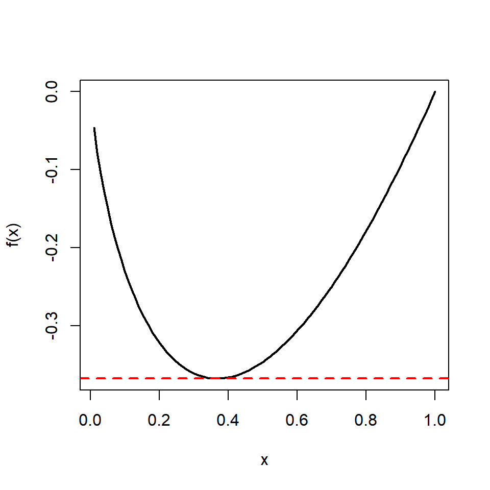

O ponto de mínimo ocorre para $x=$ 0.37 e $f(x_{min})$= -0.3678733.

### Exercício 2

A opção `asp=1` fixa a razão entre os eixos $x$ e $y$ em 1. Assim, o gráfico resultante terá as mesmas distâncias em ambos os eixos. Valores de $asp$ maiores do que 1 são úteis para gráficos de latitude e longitude, por exemplo.

### Exercício 3

As opções `xaxs` e `yaxs` controlam como o intervalo para plotar cada eixo é calculado. O estilo de eixo `"i"` (internal) encontra um intervalo com divisões suaves que caibam dentro do limite dos dados originais.

### Exercício 4

A opção `las` controla a direção em que os *labels* dos eixos são impressos, no caso `las=1` faz com que os números ou nomes das divisões dos eixos sejam impressos sempre na horizontal.

### Exercício 5

A opção `xlim` determina os limites inferior e superior para o eixo x. O comando `range(x)` retorna um vetor com o valor mínimo e o valor máximo do vetor `x`, e essa ordem é revertida com a função `rev()`. Assim, a opção `xlim=rev(range(x))` irá fazer com que o gráfico seja plotado com o eixo x revertido, do máximo para o mínimo.

## Banco de Dados

### Exercício 6

```r
require(ggplot2)
mpg
```

```
## # A tibble: 234 x 11
##    manufacturer model    displ  year   cyl trans   drv     cty   hwy fl
##    <chr>        <chr>    <dbl> <int> <int> <chr>   <chr> <int> <int> <chr>
##  1 audi         a4         1.8  1999     4 auto(l~ f        18    29 p
##  2 audi         a4         1.8  1999     4 manual~ f        21    29 p
##  3 audi         a4         2    2008     4 manual~ f        20    31 p
##  4 audi         a4         2    2008     4 auto(a~ f        21    30 p
##  5 audi         a4         2.8  1999     6 auto(l~ f        16    26 p
##  6 audi         a4         2.8  1999     6 manual~ f        18    26 p
##  7 audi         a4         3.1  2008     6 auto(a~ f        18    27 p
##  8 audi         a4 quat~   1.8  1999     4 manual~ 4        18    26 p
##  9 audi         a4 quat~   1.8  1999     4 auto(l~ 4        16    25 p
## 10 audi         a4 quat~   2    2008     4 manual~ 4        20    28 p
## # ... with 224 more rows, and 1 more variable: class <chr>
```

Após carregar o pacote e o banco de dados com o comando acima, podemos ver que as variáveis categóricas são: `manufacturer` (marca), `model` (modelo do carro), `trans` (tipo de transmissão), `drv` (tipo de direção), `fl` (tipo de combustível) e `class` (tipo do carro). As variáveis contínuas são: `displ` (capacidade do motor em litros), `year` (ano de fabricação), `cyl` (número de cilindros), `cty` (consumo médio na cidade) e `hpg` (consumo médio na estrada).

## Exercício 7

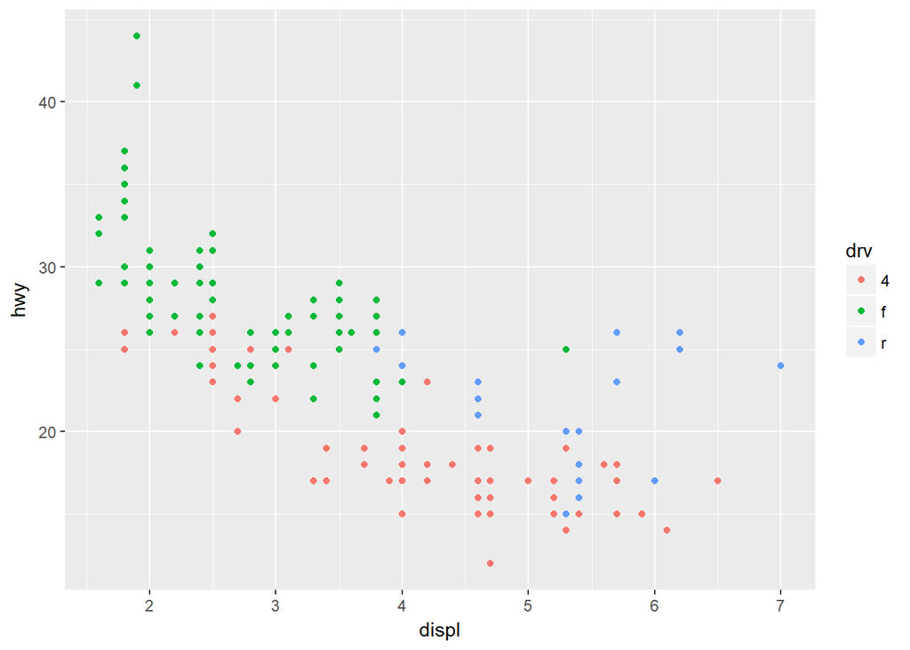

```r
ggplot(data = mpg) +
  geom_point(mapping = aes(x = displ, y = hwy, color = drv))
```

## Exercício 8

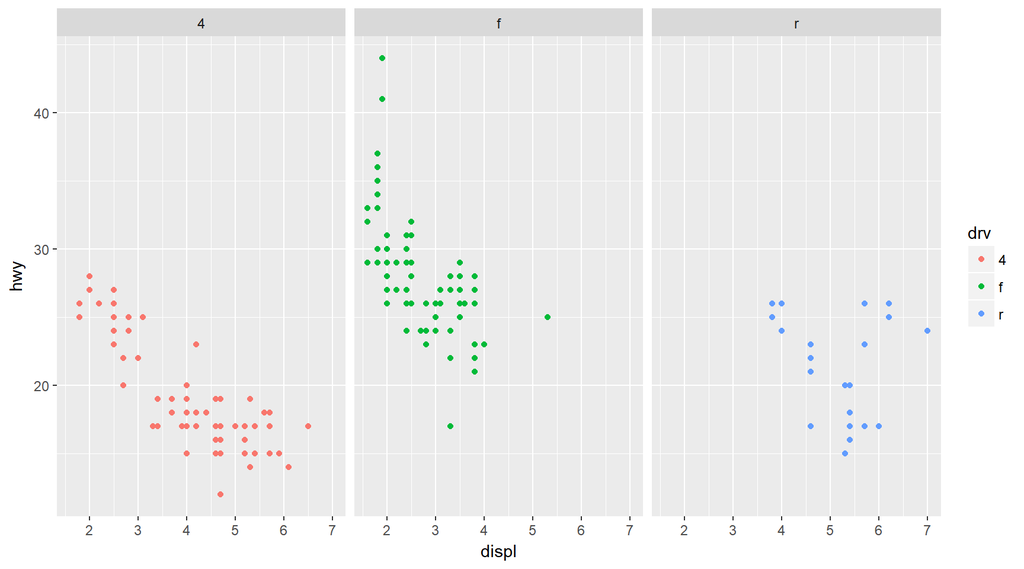

```r
ggplot(data = mpg) +
  geom_point(mapping = aes(x = displ, y = hwy, color = drv)) +
  facet_grid(. ~ drv)
```